# Vehicle LoanDefaultPrediction_EDA_Modeling

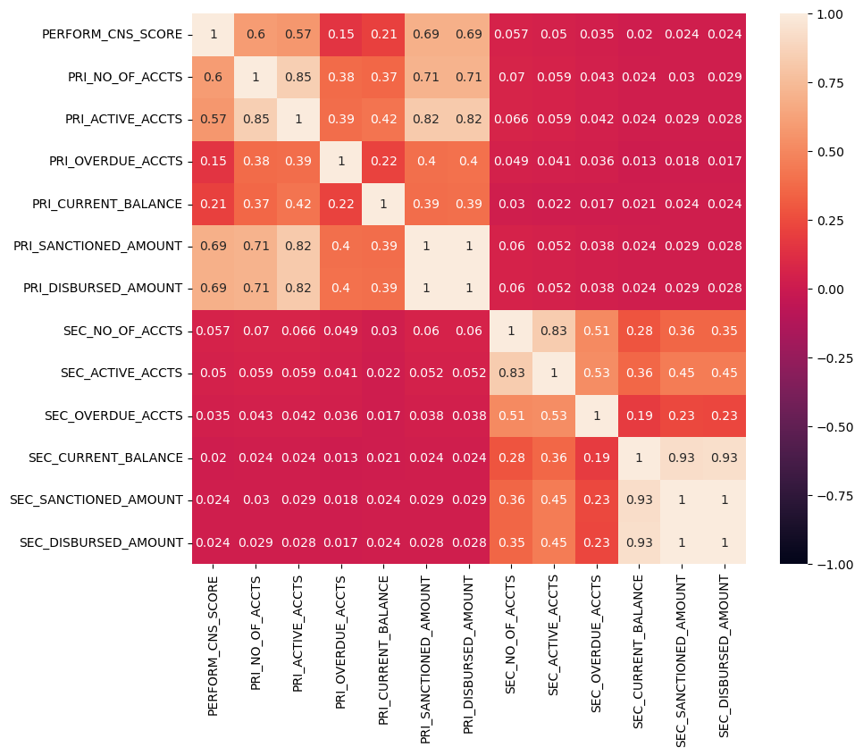

```python
loan_pri_sec_cols = loan.iloc[:,19:33]
loan_pri_sec_cols.corr()
plt.figure(figsize =(10,8))
sns.heatmap( loan_pri_sec_cols.corr(), vmin = -1 , vmax = 1 ,annot = True)
plt.title= "Corerlation Matrix - Primary and Secondary Account"
plt.show()
```

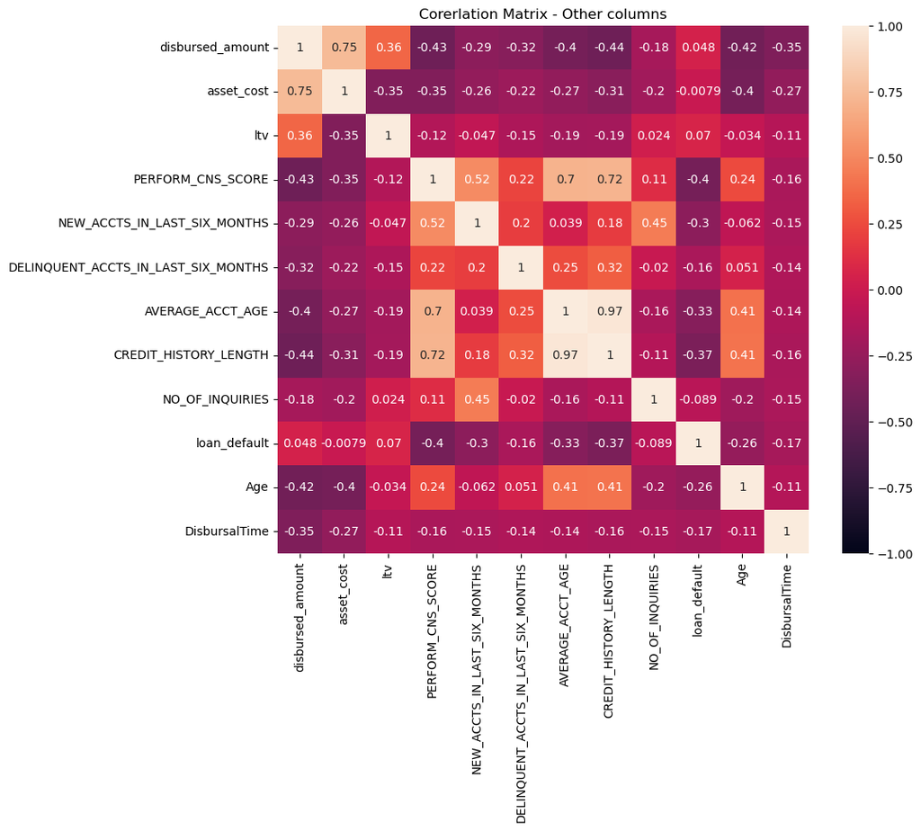

```python
columns_to_exclude = ['UniqueID' ,'branch_id','supplier_id','manufacturer_id','Current_pincode_ID','MobileNo_Avl_Flag', 'Aadhar_flag', 'PAN_flag',
                      'State_ID','Employee_code_ID','VoterID_flag', 'Driving_flag', 'Passport_flag']
loan_for_corr = loan.drop(columns = columns_to_exclude)
loan_for_corr = loan_for_corr.drop(columns=loan_pri_sec_acc)
plt.figure(figsize =(10,8))
ax=sns.heatmap( loan_for_corr.corr().corr(), vmin = -1 , vmax = 1 ,annot = True)
ax.set_title("Corerlation Matrix - Other columns")
plt.show()
```

```python
loan_for_corr.corr()
```

|  | disbursed_amount | asset_cost | ltv | PERFORM_CNS_SCORE | NEW_ACCTS_IN_LAST_SIX_MONTHS | DELINQUENT_ACCTS_IN_LAST_SIX_MONTHS | AVERAGE_ACCT_AGE | CREDIT_HISTORY_LENGTH | NO_OF_INQUIRIES | loan_default | Age | DisbursalTime |
| --- | --- | --- | --- | --- | --- | --- | --- | --- | --- | --- | --- | --- |
| disbursed_amount | 1.000000 | 0.674991 | 0.472029 | 0.008275 | 0.034689 | 0.019802 | -0.002443 | 0.007394 | 0.048842 | 0.090077 | -0.059881 | -0.093371 |
| asset_cost | 0.674991 | 1.000000 | -0.299971 | -0.054552 | -0.031718 | -0.012199 | -0.023723 | -0.030683 | -0.026510 | 0.015899 | -0.127019 | -0.096920 |
| ltv | 0.472029 | -0.299971 | 1.000000 | 0.084993 | 0.089991 | 0.044544 | 0.032715 | 0.054847 | 0.105196 | 0.098208 | 0.081120 | 0.012612 |
| PERFORM_CNS_SCORE | 0.008275 | -0.054552 | 0.084993 | 1.000000 | 0.418721 | 0.186771 | 0.521745 | 0.491484 | 0.174820 | -0.057929 | 0.168261 | 0.007250 |
| NEW_ACCTS_IN_LAST_SIX_MONTHS | 0.034689 | -0.031718 | 0.089991 | 0.418721 | 1.000000 | 0.198748 | 0.064852 | 0.235098 | 0.323311 | -0.033689 | 0.046105 | 0.003831 |
| DELINQUENT_ACCTS_IN_LAST_SIX_MONTHS | 0.019802 | -0.012199 | 0.044544 | 0.186771 | 0.198748 | 1.000000 | 0.210063 | 0.283287 | 0.091127 | 0.037370 | 0.084492 | 0.006938 |
| AVERAGE_ACCT_AGE | -0.002443 | -0.023723 | 0.032715 | 0.521745 | 0.064852 | 0.210063 | 1.000000 | 0.859840 | 0.038456 | -0.026379 | 0.265457 | 0.005090 |
| CREDIT_HISTORY_LENGTH | 0.007394 | -0.030683 | 0.054847 | 0.491484 | 0.235098 | 0.283287 | 0.859840 | 1.000000 | 0.078648 | -0.043023 | 0.285741 | 0.010739 |
| NO_OF_INQUIRIES | 0.048842 | -0.026510 | 0.105196 | 0.174820 | 0.323311 | 0.091127 | 0.038456 | 0.078648 | 1.000000 | 0.043983 | -0.010084 | -0.010012 |
| loan_default | 0.090077 | 0.015899 | 0.098208 | -0.057929 | -0.033689 | 0.037370 | -0.026379 | -0.043023 | 0.043983 | 1.000000 | -0.036647 | -0.043649 |
| Age | -0.059881 | -0.127019 | 0.081120 | 0.168261 | 0.046105 | 0.084492 | 0.265457 | 0.285741 | -0.010084 | -0.036647 | 1.000000 | -0.012134 |
| DisbursalTime | -0.093371 | -0.096920 | 0.012612 | 0.007250 | 0.003831 | 0.006938 | 0.005090 | 0.010739 | -0.010012 | -0.043649 | -0.012134 | 1.000000 |

Export prepared data to .csv for use in Power BI to create a dashboard</Span>

```python
loan.to_csv("../../02 Data/Prepared Data/Loan_PreparedData.csv")
```

```python
len(loan.columns)
```

```
44
```

Perform logistic regression modeling, predict the outcome for the test data, and validate the results using the confusion matrix.</Span>

#### Base Model

```python
loan_encoded_base = pd.get_dummies(loan, columns=['Employment_Type', 'PERFORM_CNS_SCORE_DESCRIPTION', 'Age_Group'],drop_first =True)
loan_encoded_base = loan_encoded_base.drop('UniqueID',axis=1)
loan_encoded_base = loan_encoded_base.drop('DisbursalDate',axis=1)
loan_encoded_base = loan_encoded_base.drop('Date_of_Birth',axis=1)
```

```python
# Splitting data into training and test sets
X = loan_encoded_base.drop(columns='loan_default')  # Assuming 'loan_default' is your target variable
y = loan_encoded_base['loan_default']
X_train, X_test, y_train, y_test = train_test_split(X, y, test_size=0.2, random_state=42)


# Model training

# Scaling the data (important for logistic regression)
scaler = StandardScaler()
X_train_scaled = scaler.fit_transform(X_train)
X_test_scaled = scaler.transform(X_test)

# Initialize and train the logistic regression model
model_base = LogisticRegression(max_iter=1000)
model_base.fit(X_train_scaled, y_train)
```

```
LogisticRegression(max_iter=1000)
```

```python
# Evaluation
# Predict on the test set
y_pred = model_base.predict(X_test_scaled)

# Print the classification report
print(classification_report(y_test, y_pred))

# Print accuracy
print("Accuracy:", accuracy_score(y_test, y_pred))
```

```
              precision    recall  f1-score   support

           0       0.79      1.00      0.88     36733
           1       0.45      0.01      0.02      9898

    accuracy                           0.79     46631
   macro avg       0.62      0.50      0.45     46631
weighted avg       0.72      0.79      0.70     46631

Accuracy: 0.7873303167420814
```

```
[[36635    98]
 [ 9819    79]]
```

```
<sklearn.metrics._plot.confusion_matrix.ConfusionMatrixDisplay at 0x1a21781d1f0>
```

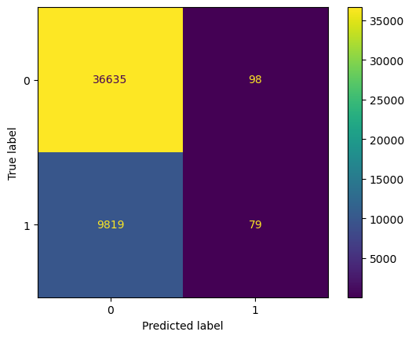

```python
from sklearn.metrics import confusion_matrix, ConfusionMatrixDisplay

# Predict on the test set
y_pred = model_base.predict(X_test_scaled)

# Get the confusion matrix
cm = confusion_matrix(y_test, y_pred)

# Print the confusion matrix
print(cm)

# Optionally, you can visualize the confusion matrix
disp = ConfusionMatrixDisplay(confusion_matrix=cm, display_labels=model_base.classes_)
disp.plot()
```

The model has a very high number of True Negatives, which means it is good at identifying non-defaulted loans. The number of True Positives is very low, indicating that the model struggles to correctly identify defaulted loans. The number of False Negatives is significantly high, which means the model is predicting many loans as non-defaulted when they actually are defaulted. We may need to handle imbalanced datasets to improve performance, especially if identifying defaults is crucial.

#### Building a Model with a Subset of Data Columns

```python
# with s subset of columns
columns_to_exclude_from_model = ['Age','PRI_SANCTIONED_AMOUNT','SEC_NO_OF_ACCTS','SEC_ACTIVE_ACCTS','SEC_OVERDUE_ACCTS',
                                 'SEC_CURRENT_BALANCE','SEC_SANCTIONED_AMOUNT','SEC_DISBURSED_AMOUNT','MobileNo_Avl_Flag','VoterID_flag']
loan_encoded_subset_subset_of_cols= loan_encoded_base.drop(columns=columns_to_exclude_from_model)
```

```python
# Splitting data into training and test sets
X = loan_encoded_subset_subset_of_cols.drop(columns='loan_default')  # Assuming 'loan_default' is your target variable
y = loan_encoded_subset_subset_of_cols['loan_default']
X_train, X_test, y_train, y_test = train_test_split(X, y, test_size=0.2, random_state=42)


# Model training

# Scaling the data (important for logistic regression)
scaler = StandardScaler()
X_train_scaled = scaler.fit_transform(X_train)
X_test_scaled = scaler.transform(X_test)

# Initialize and train the logistic regression model
model = LogisticRegression(max_iter=1000)
model.fit(X_train_scaled, y_train)
```

```
LogisticRegression(max_iter=1000)
```

```
[[36642    91]
 [ 9823    75]]
```

```
<sklearn.metrics._plot.confusion_matrix.ConfusionMatrixDisplay at 0x1a21e0b32e0>
```

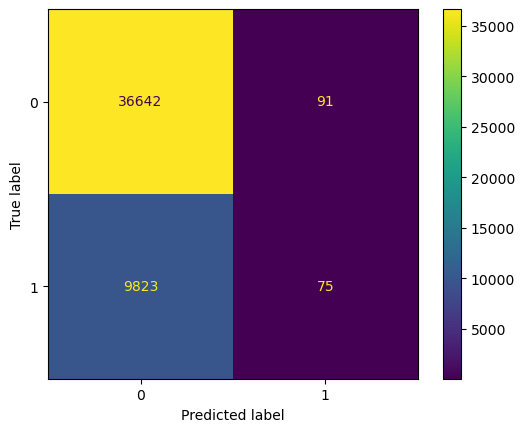

```python
from sklearn.metrics import confusion_matrix, ConfusionMatrixDisplay

# Predict on the test set
y_pred = model.predict(X_test_scaled)

# Get the confusion matrix
cm = confusion_matrix(y_test, y_pred)

# Print the confusion matrix
print(cm)

# Optionally, you can visualize the confusion matrix
disp = ConfusionMatrixDisplay(confusion_matrix=cm, display_labels=model.classes_)
disp.plot()
```

```python
# Evaluation
# Predict on the test set
y_pred = model.predict(X_test_scaled)

# Print the classification report
print(classification_report(y_test, y_pred))

# Print accuracy
print("Accuracy:", accuracy_score(y_test, y_pred))
```

```
              precision    recall  f1-score   support

           0       0.79      1.00      0.88     36733
           1       0.45      0.01      0.01      9898

    accuracy                           0.79     46631
   macro avg       0.62      0.50      0.45     46631
weighted avg       0.72      0.79      0.70     46631

Accuracy: 0.7873946516266004
```